# scRNA-seq

Population analysis

Patient data

**Cell Type population shift by treatment**

# Immune Cell population by sample

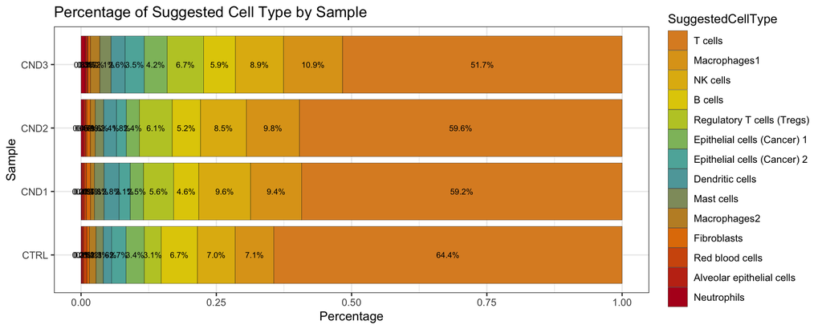

# Table 1

|  | Cell Type | CTRL % | CND1 % | CND2 % | CND3 % |
| --- | --- | --- | --- | --- | --- |
| 1 | T cells | 64.37836759129915 | 59.2346471127406 | 59.63610669493023 | 51.68539325842697 |
| 2 | Macrophages1 | 7.14428257832768 | 9.440879926672777 | 9.803921568627452 | 10.89023336214347 |
| 3 | NK cells | 6.984633805627618 | 9.578368469294226 | 8.49673202614379 | 8.902333621434746 |
| 4 | B cells | 6.685292356815006 | 4.62878093492209 | 5.228758169934641 | 5.877268798617114 |
| 5 | Regulatory T cells (Tregs) | 3.133107164238675 | 5.591200733272228 | 6.059000176647236 | 6.741573033707865 |
| 6 | Epithelial cells (Cancer) 1 | 3.372580323288764 | 2.451879010082493 | 2.420067125949479 | 4.235090751944685 |
| 7 | Epithelial cells (Cancer) 2 | 2.654160846138495 | 2.062328139321723 | 1.819466525348878 | 3.543647363872083 |
| 8 | Dendritic cells | 1.556575533825584 | 2.772685609532539 | 2.367072955308249 | 2.592912705272256 |
| 9 | Mast cells | 1.337058471363001 | 1.764436296975252 | 1.554495672142731 | 2.074330164217804 |
| 10 | Macrophages2 | 1.217321891837956 | 0.7332722273143905 | 0.9009009009009009 | 1.728608470181504 |

[output cut: 4 more lines]

# Selected Immune Cell population by sample (line graph)

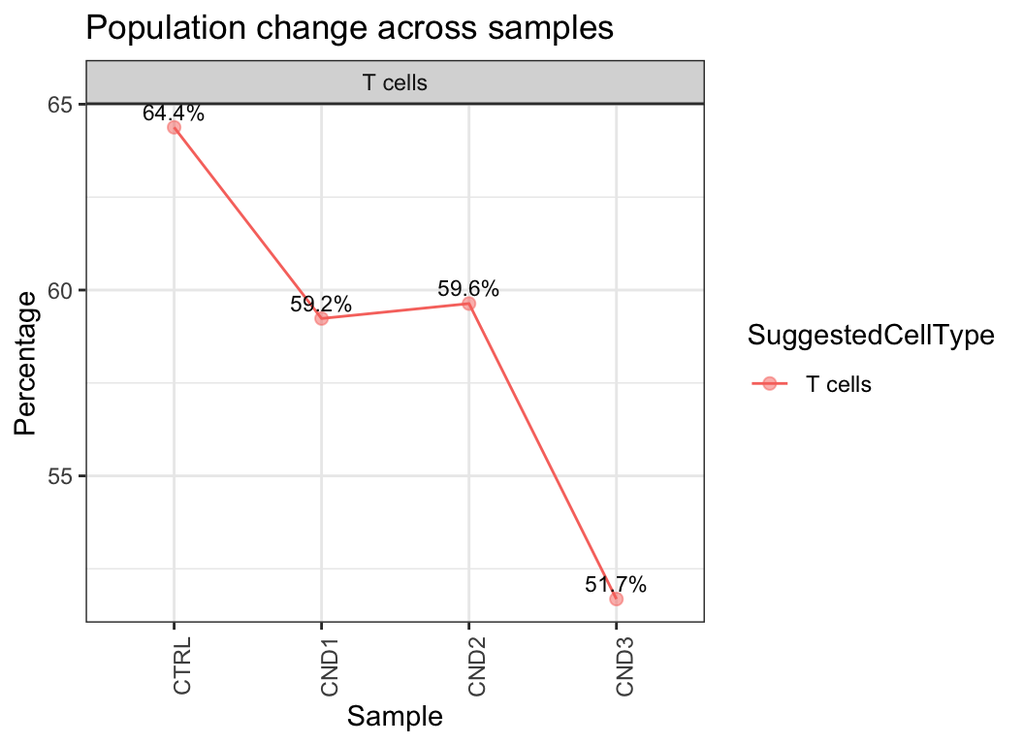

# All Immune Cell population by sample (line graph)

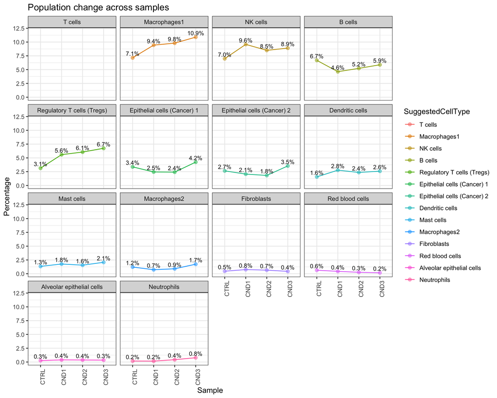

# Interpretation

**Observations**

- The T cell population shows a decrease across all treated samples when compared to the control, with the most significant reduction observed in CND3
- Macrophages (1), NK Cells, and Tregs all exhibit an increase in population across the treatments, with the largest increase occurring in CND3, except for NK Cells.
- Cancer cell populations remain relatively stable across treatments, though a slight increase is observed in CND3.

**Interpretations**

1. Suppressing T cell-mediated immune responses by this drug treatment.
2. A shift from a T cell-dominated response to a more varied immune response involving other cells that can engage in phagocytosis, immune regulation, and innate immunity.
3. CND3 exhibits a more synergistic effect compared to CND1.
4. This drug does not decrease the number of cancer cells; however, in CND3, the cancer cells might be weakened by the increased presence of macrophages and NK cells.

**Possible follow-ups Questions**

1. Identify factors that contribute to T cell suppression.
2. Identify factors that promote the increase of innate immune cells such as macrophages and NK cells.
3. Analyze changes in cancer cell characteristics between CTRL and CND3.